# DSC6 WK 14 IP Part 1

# Part 1: Dimensionality Reduction

This section of the project entails reducing your dataset to a low dimensional dataset using the t-SNE algorithm or PCA. You will be required to perform your analysis and provide insights gained from your analysis.

# Dimensionality Reduction

#Principal Component Analysis (PCA)

```r
# 2.0 Importing packages

#importing libraries

#install.packages("caret")
#loading the library
library(data.table) # load package
#install.packages(c("Rcpp","tidyverse")) # install packages to work with data frame - extends into visualization
library(tidyverse)
library("caret")
## dataset
# Dataset Url = http://bit.ly/CarreFourDataset
#
#
# Importing our dataset
#
sales_data <- read.csv('http://bit.ly/CarreFourDataset')

# Previewing the dataset
# ---
#having a look at the dataset
head(sales_data,6)
```

```
##    Invoice.ID Branch Customer.type Gender           Product.line Unit.price
## 1 750-67-8428      A        Member Female      Health and beauty      74.69
## 2 226-31-3081      C        Normal Female Electronic accessories      15.28
## 3 631-41-3108      A        Normal   Male     Home and lifestyle      46.33
## 4 123-19-1176      A        Member   Male      Health and beauty      58.22
## 5 373-73-7910      A        Normal   Male      Sports and travel      86.31
## 6 699-14-3026      C        Normal   Male Electronic accessories      85.39
##   Quantity     Tax      Date  Time     Payment   cogs gross.margin.percentage
## 1        7 26.1415  1/5/2019 13:08     Ewallet 522.83                4.761905
## 2        5  3.8200  3/8/2019 10:29        Cash  76.40                4.761905
## 3        7 16.2155  3/3/2019 13:23 Credit card 324.31                4.761905
## 4        8 23.2880 1/27/2019 20:33     Ewallet 465.76                4.761905
## 5        7 30.2085  2/8/2019 10:37     Ewallet 604.17                4.761905
## 6        7 29.8865 3/25/2019 18:30     Ewallet 597.73                4.761905
##   gross.income Rating    Total
## 1      26.1415    9.1 548.9715
## 2       3.8200    9.6  80.2200
## 3      16.2155    7.4 340.5255
## 4      23.2880    8.4 489.0480
## 5      30.2085    5.3 634.3785
## 6      29.8865    4.1 627.6165
```

## 3. previewing our dataset.

```r
#viewing the dataset
#
View(sales_data)
#
#checking the dataset dimension(displaying the number of rows and columns).
dim(sales_data)
```

```
## [1] 1000   16
```

observation: the tables has 1000 records and 16 columns. this is a wide table and that is why dimensionality reduction is needed.

### checking the colunms summary

```r
# checking the content/summary statistics of each column.
str(sales_data)
```

```
## 'data.frame':    1000 obs. of  16 variables:
##  $ Invoice.ID             : chr  "750-67-8428" "226-31-3081" "631-41-3108" "123-19-1176" ...
##  $ Branch                 : chr  "A" "C" "A" "A" ...
##  $ Customer.type          : chr  "Member" "Normal" "Normal" "Member" ...
##  $ Gender                 : chr  "Female" "Female" "Male" "Male" ...
##  $ Product.line           : chr  "Health and beauty" "Electronic accessories" "Home and lifestyle" "Health and beauty" ...
##  $ Unit.price             : num  74.7 15.3 46.3 58.2 86.3 ...
##  $ Quantity               : int  7 5 7 8 7 7 6 10 2 3 ...
##  $ Tax                    : num  26.14 3.82 16.22 23.29 30.21 ...
##  $ Date                   : chr  "1/5/2019" "3/8/2019" "3/3/2019" "1/27/2019" ...
##  $ Time                   : chr  "13:08" "10:29" "13:23" "20:33" ...
##  $ Payment                : chr  "Ewallet" "Cash" "Credit card" "Ewallet" ...
##  $ cogs                   : num  522.8 76.4 324.3 465.8 604.2 ...
##  $ gross.margin.percentage: num  4.76 4.76 4.76 4.76 4.76 ...
##  $ gross.income           : num  26.14 3.82 16.22 23.29 30.21 ...
##  $ Rating                 : num  9.1 9.6 7.4 8.4 5.3 4.1 5.8 8 7.2 5.9 ...
##  $ Total                  : num  549 80.2 340.5 489 634.4 ...
```

observation: the columns contains, character, numerical, and integer data type; in other words We have 8 numerical columns and 8 categorical columns in our dataset.

```r
### checking our dataset class
class(sales_data)
```

```
## [1] "data.frame"
```

this dataset is of the class data.frame.

### converting the data into a tibble for easy manupulation

```r
#For ease in analysis,we convert the data into a tibble
ds_sales<-as_tibble(sales_data) # there is suggestion to use as_tibble instead of as.tibble.
ds_sales
```

```
## # A tibble: 1,000 x 16
##    Invoice.ID Branch Customer.type Gender Product.line Unit.price Quantity   Tax
##    <chr>      <chr>  <chr>         <chr>  <chr>             <dbl>    <int> <dbl>
##  1 750-67-84~ A      Member        Female Health and ~       74.7        7 26.1
##  2 226-31-30~ C      Normal        Female Electronic ~       15.3        5  3.82
##  3 631-41-31~ A      Normal        Male   Home and li~       46.3        7 16.2
##  4 123-19-11~ A      Member        Male   Health and ~       58.2        8 23.3
##  5 373-73-79~ A      Normal        Male   Sports and ~       86.3        7 30.2
##  6 699-14-30~ C      Normal        Male   Electronic ~       85.4        7 29.9
##  7 355-53-59~ A      Member        Female Electronic ~       68.8        6 20.7
##  8 315-22-56~ C      Normal        Female Home and li~       73.6       10 36.8
##  9 665-32-91~ A      Member        Female Health and ~       36.3        2  3.63
## 10 692-92-55~ B      Member        Female Food and be~       54.8        3  8.23
## # ... with 990 more rows, and 8 more variables: Date <chr>, Time <chr>,
## #   Payment <chr>, cogs <dbl>, gross.margin.percentage <dbl>,
## #   gross.income <dbl>, Rating <dbl>, Total <dbl>
```

###checking dataset summary

```r
### dataset summary
summary(ds_sales)
```

```
##   Invoice.ID           Branch          Customer.type         Gender
##  Length:1000        Length:1000        Length:1000        Length:1000
##  Class :character   Class :character   Class :character   Class :character
##  Mode  :character   Mode  :character   Mode  :character   Mode  :character
##
##
##
##  Product.line         Unit.price       Quantity          Tax
##  Length:1000        Min.   :10.08   Min.   : 1.00   Min.   : 0.5085
##  Class :character   1st Qu.:32.88   1st Qu.: 3.00   1st Qu.: 5.9249
##  Mode  :character   Median :55.23   Median : 5.00   Median :12.0880
##                     Mean   :55.67   Mean   : 5.51   Mean   :15.3794
##                     3rd Qu.:77.94   3rd Qu.: 8.00   3rd Qu.:22.4453
##                     Max.   :99.96   Max.   :10.00   Max.   :49.6500
##      Date               Time             Payment               cogs
##  Length:1000        Length:1000        Length:1000        Min.   : 10.17
##  Class :character   Class :character   Class :character   1st Qu.:118.50
##  Mode  :character   Mode  :character   Mode  :character   Median :241.76
##                                                           Mean   :307.59
##                                                           3rd Qu.:448.90
##                                                           Max.   :993.00
##  gross.margin.percentage  gross.income         Rating           Total
##  Min.   :4.762           Min.   : 0.5085   Min.   : 4.000   Min.   :  10.68
##  1st Qu.:4.762           1st Qu.: 5.9249   1st Qu.: 5.500   1st Qu.: 124.42
##  Median :4.762           Median :12.0880   Median : 7.000   Median : 253.85
##  Mean   :4.762           Mean   :15.3794   Mean   : 6.973   Mean   : 322.97
##  3rd Qu.:4.762           3rd Qu.:22.4453   3rd Qu.: 8.500   3rd Qu.: 471.35
##  Max.   :4.762           Max.   :49.6500   Max.   :10.000   Max.   :1042.65
```

observation: this gives us a preview of mean, median, maximum of the colunms.

## Data cleaning

###2.0 missing values

```r
# Identify missing data in our entire dataset using is.na() function
#

colSums(is.na(ds_sales))
```

```
##              Invoice.ID                  Branch           Customer.type
##                       0                       0                       0
##                  Gender            Product.line              Unit.price
##                       0                       0                       0
##                Quantity                     Tax                    Date
##                       0                       0                       0
##                    Time                 Payment                    cogs
##                       0                       0                       0
## gross.margin.percentage            gross.income                  Rating
##                       0                       0                       0
##                   Total
##                       0
```

### Checking for missing values using the complete function

```r
# using complete function

ds_sales[!complete.cases(ds_sales),]
```

```
## # A tibble: 0 x 16
## # ... with 16 variables: Invoice.ID <chr>, Branch <chr>, Customer.type <chr>,
## #   Gender <chr>, Product.line <chr>, Unit.price <dbl>, Quantity <int>,
## #   Tax <dbl>, Date <chr>, Time <chr>, Payment <chr>, cogs <dbl>,
## #   gross.margin.percentage <dbl>, gross.income <dbl>, Rating <dbl>,
## #   Total <dbl>
```

observation: there is no missing values.

### 3.0 Duplicated Data

```r
#Identifying Duplicated Data
#
dup_rows <- ds_sales[duplicated(ds_sales),]
dup_rows
```

```
## # A tibble: 0 x 16
## # ... with 16 variables: Invoice.ID <chr>, Branch <chr>, Customer.type <chr>,
## #   Gender <chr>, Product.line <chr>, Unit.price <dbl>, Quantity <int>,
## #   Tax <dbl>, Date <chr>, Time <chr>, Payment <chr>, cogs <dbl>,
## #   gross.margin.percentage <dbl>, gross.income <dbl>, Rating <dbl>,
## #   Total <dbl>
```

```r
# checking for duplicated records
anyDuplicated(ds_sales)
```

```
## [1] 0
```

observation: there is no duplicates in our dataset.

### checking for outlier

```r
# install the package
#install.packages("ggstatsplot")
# Load the package
library(devtools)
#library(ggstatsplot)
```

###3.2a Identifying the numeric class in the data and evaluating if there are any outliers

```r
#Checking the data types of the columns
#
Numeric<- ds_sales %>% select_if(is.numeric)
Numeric
```

```
## # A tibble: 1,000 x 8
##    Unit.price Quantity   Tax  cogs gross.margin.perce~ gross.income Rating Total
##         <dbl>    <int> <dbl> <dbl>               <dbl>        <dbl>  <dbl> <dbl>
##  1       74.7        7 26.1  523.                 4.76        26.1     9.1 549.
##  2       15.3        5  3.82  76.4                4.76         3.82    9.6  80.2
##  3       46.3        7 16.2  324.                 4.76        16.2     7.4 341.
##  4       58.2        8 23.3  466.                 4.76        23.3     8.4 489.
##  5       86.3        7 30.2  604.                 4.76        30.2     5.3 634.
##  6       85.4        7 29.9  598.                 4.76        29.9     4.1 628.
##  7       68.8        6 20.7  413.                 4.76        20.7     5.8 434.
##  8       73.6       10 36.8  736.                 4.76        36.8     8   772.
##  9       36.3        2  3.63  72.5                4.76         3.63    7.2  76.1
## 10       54.8        3  8.23 165.                 4.76         8.23    5.9 173.
## # ... with 990 more rows
```

observation: we have 8 numerical variables.

### visualizing outliers

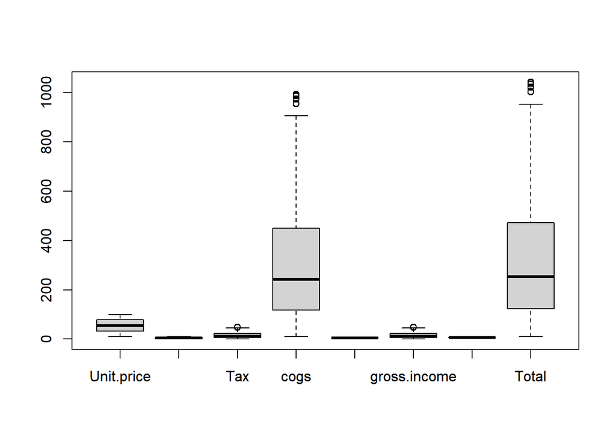

```
##  [1]   47.790   49.490   49.650   47.720   48.605   49.260   48.750   48.685
##  [9]   48.690  955.800  989.800  993.000  954.400  972.100  985.200  975.000
## [17]  973.700  973.800   47.790   49.490   49.650   47.720   48.605   49.260
## [25]   48.750   48.685   48.690 1003.590 1039.290 1042.650 1002.120 1020.705
## [33] 1034.460 1023.750 1022.385 1022.490
```

```r
# Create a boxplot of the dataset, outliers are shown as two distinct points
boxplot(Numeric)$out
```

observation: there is outliers in Tax,cogs,gross income, and Total variables. however they look genuine thus we will not remove them.

## 4.0 Creating a dataset for PCA

```r
# Selecting the numerical data (excluding the categorical variables)
# ---
#
numeric <- ds_sales[,c(6:8,12:16)]
head(numeric)
```

```
## # A tibble: 6 x 8
##   Unit.price Quantity   Tax  cogs gross.margin.percen~ gross.income Rating Total
##        <dbl>    <int> <dbl> <dbl>                <dbl>        <dbl>  <dbl> <dbl>
## 1       74.7        7 26.1  523.                  4.76        26.1     9.1 549.
## 2       15.3        5  3.82  76.4                 4.76         3.82    9.6  80.2
## 3       46.3        7 16.2  324.                  4.76        16.2     7.4 341.
## 4       58.2        8 23.3  466.                  4.76        23.3     8.4 489.
## 5       86.3        7 30.2  604.                  4.76        30.2     5.3 634.
## 6       85.4        7 29.9  598.                  4.76        29.9     4.1 628.
```

observation: PCA only works with numerical values, thus we selected numerical variables from our dataset.

## ### Ensuring our variances is not 0

```r
# Ensuring our variances is not 0, this replaces center argument.
#
x_zero_var <- numeric[ , which(apply(numeric, 2, var) != 0)]
head(x_zero_var)
```

```
## # A tibble: 6 x 7
##   Unit.price Quantity   Tax  cogs gross.income Rating Total
##        <dbl>    <int> <dbl> <dbl>        <dbl>  <dbl> <dbl>
## 1       74.7        7 26.1  523.         26.1     9.1 549.
## 2       15.3        5  3.82  76.4         3.82    9.6  80.2
## 3       46.3        7 16.2  324.         16.2     7.4 341.
## 4       58.2        8 23.3  466.         23.3     8.4 489.
## 5       86.3        7 30.2  604.         30.2     5.3 634.
## 6       85.4        7 29.9  598.         29.9     4.1 628.
```

observation, apply function is used instead of center to ensure there is no zero variance. this also helps in ensuring no column has zero mean. in this case one column “gross.margin.percentage” was removed.

```r
#We then pass pca_numeric to the prcomp(). We also set one arguments, scale,
# to be TRUE then preview our object with summary
pc_dt <- prcomp(x_zero_var,scale=TRUE)
summary(pc_dt)
```

```
## Importance of components:
##                           PC1    PC2    PC3     PC4       PC5       PC6
## Standard deviation     2.2185 1.0002 0.9939 0.30001 2.981e-16 1.493e-16
## Proportion of Variance 0.7031 0.1429 0.1411 0.01286 0.000e+00 0.000e+00
## Cumulative Proportion  0.7031 0.8460 0.9871 1.00000 1.000e+00 1.000e+00
##                              PC7
## Standard deviation     9.831e-17
## Proportion of Variance 0.000e+00
## Cumulative Proportion  1.000e+00
```

observation:

we obtain 7 principal components, each which explain a percentage of the total variation of the Dataset.

PC1 has 2.22 of standard deviation, PC2 has 1.0 of standard deviation, PC3 has 0.99 of standard deviation etc.

### we can plot the principal components for visualization using plot(), and type.

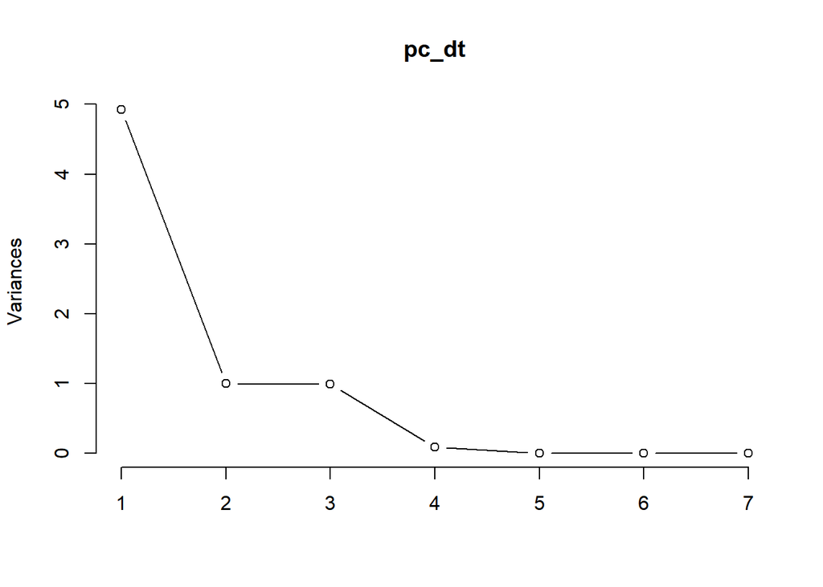

```r
plot(pc_dt,type = 'l')
```

Observation: Most of the variability in our data are in the first and second component of our PCa. Variance explained keeps on reducing as PC increases.

```r
# Calling str() to have a look at your PCA object
# ---
#
str(pc_dt)
```

```
## List of 5
##  $ sdev    : num [1:7] 2.22 1.00 9.94e-01 3.00e-01 2.98e-16 ...
##  $ rotation: num [1:7, 1:7] -0.292 -0.325 -0.45 -0.45 -0.45 ...
##   ..- attr(*, "dimnames")=List of 2
##   .. ..$ : chr [1:7] "Unit.price" "Quantity" "Tax" "cogs" ...
##   .. ..$ : chr [1:7] "PC1" "PC2" "PC3" "PC4" ...
##  $ center  : Named num [1:7] 55.67 5.51 15.38 307.59 15.38 ...
##   ..- attr(*, "names")= chr [1:7] "Unit.price" "Quantity" "Tax" "cogs" ...
##  $ scale   : Named num [1:7] 26.49 2.92 11.71 234.18 11.71 ...
##   ..- attr(*, "names")= chr [1:7] "Unit.price" "Quantity" "Tax" "cogs" ...
##  $ x       : num [1:1000, 1:7] -2.005 2.306 -0.186 -1.504 -2.8 ...
##   ..- attr(*, "dimnames")=List of 2
##   .. ..$ : NULL
##   .. ..$ : chr [1:7] "PC1" "PC2" "PC3" "PC4" ...
##  - attr(*, "class")= chr "prcomp"
```

Observation: Here we note that our pca object: The center point ($center presnted by apply()function), scaling ($scale),standard deviation(sdev) of each principal component for example standard deviation for pc1 is 2.22.

The relationship (correlation or anticorrelation, etc) between the initial variables and the principal components ($rotation) for example the correlation of pc1 is -0.292

The values of each sample in terms of the principal components ($x) for example the value of pc1 is -2.005.

## visualizing our PCA

```r
# we install packages to assist in visualization
#
# Installing our ggbiplot visualization package
#
#remotes::install_github('vqv/ggbiplot') ##There is no install_github function in base R, we use the remotes package.
#library(ggbiplot)
```

```r
#installing devtools
#install.packages('devtools')
#
library(devtools)
```

```r
# Then Loading our libraries
#

library(plyr)
library(scales)
library(grid)
library(tidyverse)
```

## plotting our pca

```r
# We will now plot our pca. This will provide us with some very useful insights i.e.
# which  are most similar to each other.
#ggbiplot(pc_dt, scale =0.4)
```

[output not shown]

observation:

## selecting PC1 and PC2,PC3 for ploting

```r
#we want to include other colunms to be plotted as well
pc_dt1 <- cbind(ds_sales,pc_dt$x[,1:3])
head(pc_dt1)
```

```
##    Invoice.ID Branch Customer.type Gender           Product.line Unit.price
## 1 750-67-8428      A        Member Female      Health and beauty      74.69
## 2 226-31-3081      C        Normal Female Electronic accessories      15.28
## 3 631-41-3108      A        Normal   Male     Home and lifestyle      46.33
## 4 123-19-1176      A        Member   Male      Health and beauty      58.22
## 5 373-73-7910      A        Normal   Male      Sports and travel      86.31
## 6 699-14-3026      C        Normal   Male Electronic accessories      85.39
##   Quantity     Tax      Date  Time     Payment   cogs gross.margin.percentage
## 1        7 26.1415  1/5/2019 13:08     Ewallet 522.83                4.761905
## 2        5  3.8200  3/8/2019 10:29        Cash  76.40                4.761905
## 3        7 16.2155  3/3/2019 13:23 Credit card 324.31                4.761905
## 4        8 23.2880 1/27/2019 20:33     Ewallet 465.76                4.761905
## 5        7 30.2085  2/8/2019 10:37     Ewallet 604.17                4.761905
## 6        7 29.8865 3/25/2019 18:30     Ewallet 597.73                4.761905
##   gross.income Rating    Total        PC1         PC2        PC3
## 1      26.1415    9.1 548.9715 -2.0053643  1.26346268  0.2568841
## 2       3.8200    9.6  80.2200  2.3061287  1.04275950  1.4649372
## 3      16.2155    7.4 340.5255 -0.1863586  0.03066994  0.6532131
## 4      23.2880    8.4 489.0480 -1.5041579  0.63584271  0.7628867
## 5      30.2085    5.3 634.3785 -2.7995421 -0.68766184 -0.8044468
## 6      29.8865    4.1 627.6165 -2.7529768 -1.35302951 -1.0204669
```

## plotting PCa with added information.

```r
# Adding more detail to the plot, we provide arguments rownames as labels
#
#ggbiplot(pc_dt, col=Product.line(pc_dt1), obs.scale = 1, var.scale =1.5)
```

[output not shown]

## plotting PC1 and PC2 to check the products by grouping based on gender.

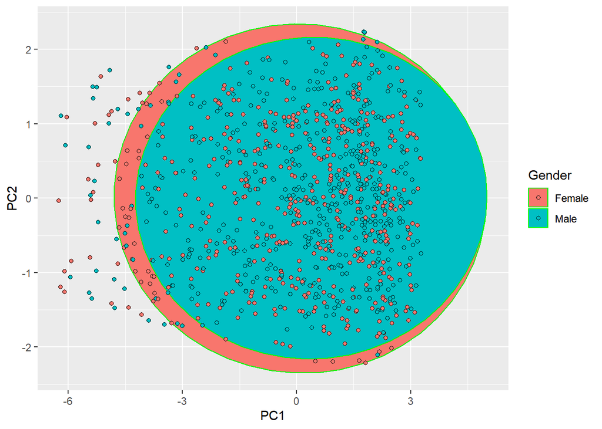

```r
ggplot(pc_dt1,aes(PC1,PC2,PC3, col=Product.line,fill=Gender))+
 stat_ellipse(geom = "polygon",col='green',alpha=1)+
 geom_point(col='black',shape=21)
```

observation: customers overlap in so many area hence using principal component analysis to group them into different categories has failed.

# Part 2

Part 2: Feature Selection

This section requires you to perform feature selection through the use of the unsupervised learning methods learned earlier this week. You will be required to perform your analysis and provide insights on the features that contribute the most information to the dataset.

### 1. Filter method feature selection

We can use the find Correlation function included in the caret package to create a subset of variabes.

This function would allows us to remove redundancy by correlation using the given dataset.

It would search through a correlation matrix and return a vector of integers corresponding to the columns, to remove or reduce pair-wise correlations.

## previewing the dataset to be used

```r
#dataset to be used for feature selection
#
fs_df<- pc_dt1
head(fs_df)
```

```
##    Invoice.ID Branch Customer.type Gender           Product.line Unit.price
## 1 750-67-8428      A        Member Female      Health and beauty      74.69
## 2 226-31-3081      C        Normal Female Electronic accessories      15.28
## 3 631-41-3108      A        Normal   Male     Home and lifestyle      46.33
## 4 123-19-1176      A        Member   Male      Health and beauty      58.22
## 5 373-73-7910      A        Normal   Male      Sports and travel      86.31
## 6 699-14-3026      C        Normal   Male Electronic accessories      85.39
##   Quantity     Tax      Date  Time     Payment   cogs gross.margin.percentage
## 1        7 26.1415  1/5/2019 13:08     Ewallet 522.83                4.761905
## 2        5  3.8200  3/8/2019 10:29        Cash  76.40                4.761905
## 3        7 16.2155  3/3/2019 13:23 Credit card 324.31                4.761905
## 4        8 23.2880 1/27/2019 20:33     Ewallet 465.76                4.761905
## 5        7 30.2085  2/8/2019 10:37     Ewallet 604.17                4.761905
## 6        7 29.8865 3/25/2019 18:30     Ewallet 597.73                4.761905
##   gross.income Rating    Total        PC1         PC2        PC3
## 1      26.1415    9.1 548.9715 -2.0053643  1.26346268  0.2568841
## 2       3.8200    9.6  80.2200  2.3061287  1.04275950  1.4649372
## 3      16.2155    7.4 340.5255 -0.1863586  0.03066994  0.6532131
## 4      23.2880    8.4 489.0480 -1.5041579  0.63584271  0.7628867
## 5      30.2085    5.3 634.3785 -2.7995421 -0.68766184 -0.8044468
## 6      29.8865    4.1 627.6165 -2.7529768 -1.35302951 -1.0204669
```

### getting the numeric variables

```r
#
#Checking the data types of the columns
#
fs_num<- fs_df %>% select_if(is.numeric)
fs_num
```

[output not shown]

[output cut: 1987 more lines]

## dropping “gross.margin.percentage” columns since it had been removed during pca process.

```r
# selecting highly correlated columns to be dropped
to_drop <- c("gross.margin.percentage")
#
#dropping the highly correlated colunms
#
fs_num <- fs_num[, !names(fs_num) %in% to_drop]
head(fs_num)
```

```
##   Unit.price Quantity     Tax   cogs gross.income Rating    Total        PC1
## 1      74.69        7 26.1415 522.83      26.1415    9.1 548.9715 -2.0053643
## 2      15.28        5  3.8200  76.40       3.8200    9.6  80.2200  2.3061287
## 3      46.33        7 16.2155 324.31      16.2155    7.4 340.5255 -0.1863586
## 4      58.22        8 23.2880 465.76      23.2880    8.4 489.0480 -1.5041579
## 5      86.31        7 30.2085 604.17      30.2085    5.3 634.3785 -2.7995421
## 6      85.39        7 29.8865 597.73      29.8865    4.1 627.6165 -2.7529768
##           PC2        PC3
## 1  1.26346268  0.2568841
## 2  1.04275950  1.4649372
## 3  0.03066994  0.6532131
## 4  0.63584271  0.7628867
## 5 -0.68766184 -0.8044468
## 6 -1.35302951 -1.0204669
```

### installing packages to be used in feature selection filter method.

```r
# Installing and loading our caret package
# ---
#
#        suppressMessages(if
#                         (!require(caret, quietly=TRUE))
#               install.packages("caret")))
library(caret)
```

```r
# Installing and loading the corrplot package for plotting
# ---
#
#suppressWarnings(
 #       suppressMessages(if
  #                       (!require(corrplot, quietly=TRUE))
  #              install.packages("corrplot")))
library(corrplot)
# Calculating the correlation matrix
# ---
#
c_matrix <- cor(fs_num)
c_matrix
```

```
##                Unit.price    Quantity          Tax         cogs gross.income
## Unit.price    1.000000000  0.01077756  0.633962089  0.633962089  0.633962089
## Quantity      0.010777564  1.00000000  0.705510186  0.705510186  0.705510186
## Tax           0.633962089  0.70551019  1.000000000  1.000000000  1.000000000
## cogs          0.633962089  0.70551019  1.000000000  1.000000000  1.000000000
## gross.income  0.633962089  0.70551019  1.000000000  1.000000000  1.000000000
## Rating       -0.008777507 -0.01581490 -0.036441705 -0.036441705 -0.036441705
## Total         0.633962089  0.70551019  1.000000000  1.000000000  1.000000000
## PC1          -0.647279280 -0.71997117 -0.997841555 -0.997841555 -0.997841555
## PC2           0.270921037 -0.21279093  0.004197195  0.004197195  0.004197195
## PC3          -0.689339359  0.62927754  0.001824964  0.001824964  0.001824964
##                    Rating        Total           PC1           PC2
## Unit.price   -0.008777507  0.633962089 -6.472793e-01  2.709210e-01
## Quantity     -0.015814905  0.705510186 -7.199712e-01 -2.127909e-01
## Tax          -0.036441705  1.000000000 -9.978416e-01  4.197195e-03
## cogs         -0.036441705  1.000000000 -9.978416e-01  4.197195e-03
## gross.income -0.036441705  1.000000000 -9.978416e-01  4.197195e-03
## Rating        1.000000000 -0.036441705  4.144017e-02  9.389628e-01
## Total        -0.036441705  1.000000000 -9.978416e-01  4.197195e-03
## PC1           0.041440174 -0.997841555  1.000000e+00 -3.821195e-16
## PC2           0.938962831  0.004197195 -3.821195e-16  1.000000e+00
## PC3           0.341472990  0.001824964  6.660201e-16 -1.933123e-16
##                        PC3
## Unit.price   -6.893394e-01
## Quantity      6.292775e-01
## Tax           1.824964e-03
## cogs          1.824964e-03
## gross.income  1.824964e-03
## Rating        3.414730e-01
## Total         1.824964e-03
## PC1           6.660201e-16
## PC2          -1.933123e-16
## PC3           1.000000e+00
```

```r
# Find attributes that are highly correlated
# ---
#
h_cor <- findCorrelation(c_matrix, cutoff=0.75)
h_cor
```

```
## [1] 8 3 4 5 9
```

```r
#
names(fs_num[,h_cor])
```

```
## [1] "PC1"          "Tax"          "cogs"         "gross.income" "PC2"
```

observation: Attribute 8,3,4,5, and 9 are highly correlated; they are PC1, Tax, Cogs, gross.income, and PC2.

we used the PC1 components as engineered features and now we find that they are high correlated features.

We could compare their correlation with the target variable and then decide on which ones to use for the modeling and which ones not to use. The ones with the highest correlation to the target will be selected for modeling.

### Dropping variable with high correlation.

```r
# We can remove the variables with a higher correlation
# and comparing the results graphically as shown below
#
# Removing Redundant Features
# ---
#
h_cor2<-fs_num[-h_cor]
h_cor2
```

[output not shown]

[output cut: 986 more lines]

observation:

we now remain with 5 colunms after removing the higly correlated features.

###. performing the comparison

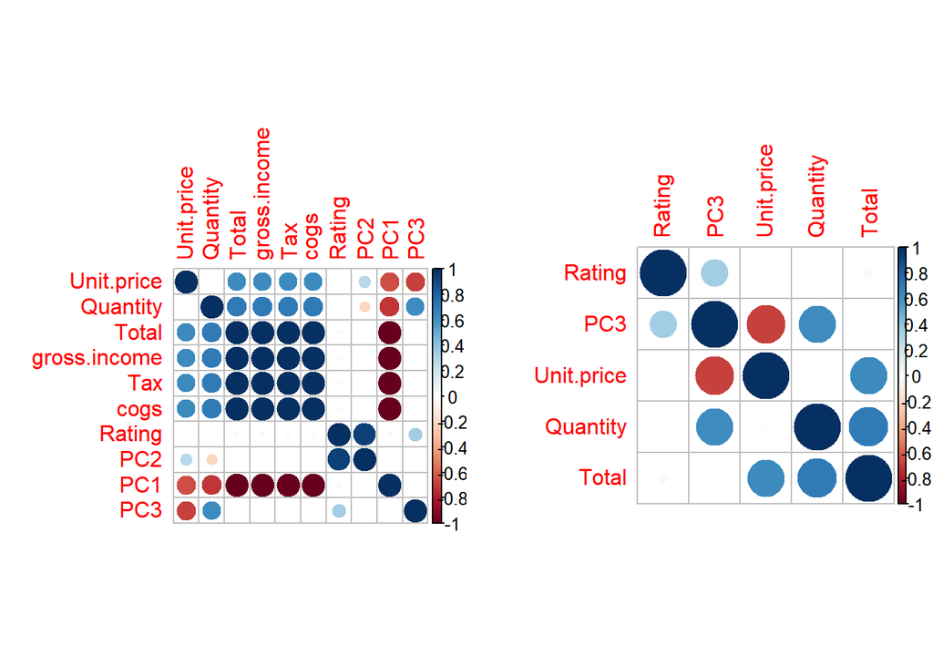

```r
# Performing our graphical comparison
# ---
#
par(mfrow = c(1, 2))
corrplot(c_matrix, order = "hclust")
corrplot(cor(h_cor2), order = "hclust")
```

observation: Removing all the highly correlated features is not ideal , we could have removed one variable in each correlated pairs if we wanted to build the model. removing one pair in each would reduce Multicollinearity as it remove redundancy.

### 2. Wrapper Methods feature selection

We use the clustvarsel package that contains an implementation of wrapper methods.

The clustvarsel function will implement variable section methodology for model-based clustering to find the optimal subset of variables in a dataset.

### previewing the dataset to be used for this method

```r
#getting the dataset
w_df <- ds_sales
#
#checking the dateset
#
head(w_df)
```

```
## # A tibble: 6 x 16
##   Invoice.ID Branch Customer.type Gender Product.line Unit.price Quantity   Tax
##   <chr>      <chr>  <chr>         <chr>  <chr>             <dbl>    <int> <dbl>
## 1 750-67-84~ A      Member        Female Health and ~       74.7        7 26.1
## 2 226-31-30~ C      Normal        Female Electronic ~       15.3        5  3.82
## 3 631-41-31~ A      Normal        Male   Home and li~       46.3        7 16.2
## 4 123-19-11~ A      Member        Male   Health and ~       58.2        8 23.3
## 5 373-73-79~ A      Normal        Male   Sports and ~       86.3        7 30.2
## 6 699-14-30~ C      Normal        Male   Electronic ~       85.4        7 29.9
## # ... with 8 more variables: Date <chr>, Time <chr>, Payment <chr>, cogs <dbl>,
## #   gross.margin.percentage <dbl>, gross.income <dbl>, Rating <dbl>,
## #   Total <dbl>
```

## 4.0 chosing numerical variables

```r
# Selecting the numerical data (excluding the categorical variables)
# ---
#
w_num <- ds_sales[,c(6:8,12:16)]
head(w_num)
```

```
## # A tibble: 6 x 8
##   Unit.price Quantity   Tax  cogs gross.margin.percen~ gross.income Rating Total
##        <dbl>    <int> <dbl> <dbl>                <dbl>        <dbl>  <dbl> <dbl>
## 1       74.7        7 26.1  523.                  4.76        26.1     9.1 549.
## 2       15.3        5  3.82  76.4                 4.76         3.82    9.6  80.2
## 3       46.3        7 16.2  324.                  4.76        16.2     7.4 341.
## 4       58.2        8 23.3  466.                  4.76        23.3     8.4 489.
## 5       86.3        7 30.2  604.                  4.76        30.2     5.3 634.
## 6       85.4        7 29.9  598.                  4.76        29.9     4.1 628.
```

### dropping the colunm

```r
## dropping "gross.margin.percentage" columns since it leads to zero variance.

# selecting highly correlated columns to be dropped
to_drop <- c("gross.margin.percentage")
#
#dropping the colunm
#
w_num <- w_num[, !names(w_num) %in% to_drop]
head(w_num)
```

```
## # A tibble: 6 x 7
##   Unit.price Quantity   Tax  cogs gross.income Rating Total
##        <dbl>    <int> <dbl> <dbl>        <dbl>  <dbl> <dbl>
## 1       74.7        7 26.1  523.         26.1     9.1 549.
## 2       15.3        5  3.82  76.4         3.82    9.6  80.2
## 3       46.3        7 16.2  324.         16.2     7.4 341.
## 4       58.2        8 23.3  466.         23.3     8.4 489.
## 5       86.3        7 30.2  604.         30.2     5.3 634.
## 6       85.4        7 29.9  598.         29.9     4.1 628.
```

### normalizing the datset.

```r
# normalizing our dataset by use of scale function.
#
library(dplyr)
w_norm <- as.data.frame(scale(w_num))
#
#previewing the scaled dataset.
head(w_norm)
```

```
##    Unit.price   Quantity         Tax        cogs gross.income     Rating
## 1  0.71780097  0.5096752  0.91914693  0.91914693   0.91914693  1.2378240
## 2 -1.52454035 -0.1744526 -0.98723557 -0.98723557  -0.98723557  1.5287619
## 3 -0.35260468  0.5096752  0.07141032  0.07141032   0.07141032  0.2486355
## 4  0.09616553  0.8517391  0.67544187  0.67544187   0.67544187  0.8305111
## 5  1.15638044  0.5096752  1.26649176  1.26649176   1.26649176 -0.9733034
## 6  1.12165642  0.5096752  1.23899114  1.23899114   1.23899114 -1.6715541
##         Total
## 1  0.91914693
## 2 -0.98723557
## 3  0.07141032
## 4  0.67544187
## 5  1.26649176
## 6  1.23899114
```

observation: our data is now scaled and is now on the same scale.

### installing the packages to be used

```r
# Installing and loading our clustvarsel package
# ---
#
#install.packages("clustvarsel")

library(clustvarsel)
# Installing and loading our mclust package
# ---
#
#suppressWarnings(
  #      suppressMessages(if
  #                       (!require(mclust, quietly=TRUE))
   #             install.packages("mclust")))
library(mclust)
```

### selecting the best features

```r
# Sequential forward greedy search (default)
# ---
#
out = clustvarsel(w_norm, G = 1:7)
out
```

```
## ------------------------------------------------------
## Variable selection for Gaussian model-based clustering
## Stepwise (forward/backward) greedy search
## ------------------------------------------------------
##
##  Variable proposed Type of step  BICclust Model G   BICdiff Decision
##                Tax          Add -2460.877     V 4  389.8147 Accepted
##           Quantity          Add -3599.179   VEV 7 1030.6521 Accepted
##         Unit.price          Add -1707.881   EVV 7 3236.0143 Accepted
##         Unit.price       Remove -3599.179   VEV 7 3236.0143 Rejected
##             Rating          Add -4815.681   EVV 7 -257.1079 Rejected
##         Unit.price       Remove -3599.179   VEV 7 3236.0143 Rejected
##
## Selected subset: Tax, Quantity, Unit.price
```

observation: 3 variables were accepted, they include Tax, Quantity, and unit price.

```r
# The selection algorithm would indicate that the subset
# we use for the clustering model is composed of variables Tax, Quantity, and Unit price
# and that other variables should be rejected.
# Having identified the variables that we use, we proceed to build the clustering model:
# ---
#

Subset1 = w_norm[out$subset]
mod = Mclust(Subset1, G = 1:3)
summary(mod)
```

```
## ----------------------------------------------------
## Gaussian finite mixture model fitted by EM algorithm
## ----------------------------------------------------
##
## Mclust EVV (ellipsoidal, equal volume) model with 3 components:
##
##  log-likelihood    n df       BIC      ICL
##       -1846.246 1000 27 -3879.002 -3986.31
##
## Clustering table:
##   1   2   3
## 319 357 324
```

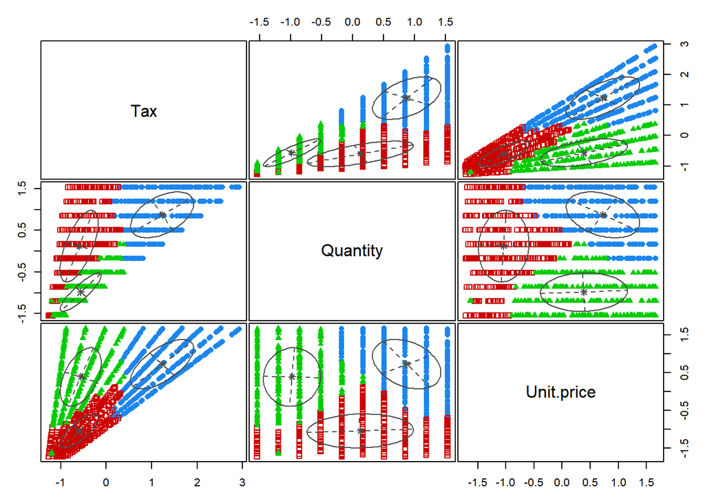

```r
plot(mod,c("classification"))
```

observation: this is the distribution of 3 clusters.

### Embedded Methods future selection

We will use the ewkm function from the wskm package.

This is a weighted subspace clustering algorithm that is well suited to very high dimensional data.

### installing the package to use

```r
# We install and load our wskm package
# ---
#
#suppressWarnings(
 #       suppressMessages(if
     #                    (!require(wskm, quietly=TRUE))
     #           install.packages("wskm")))
library(wskm)
set.seed(6)
model <- ewkm(w_norm[1:7], 4, lambda=2, maxiter=1000)
model
```

```
## K-means clustering with 4 clusters of sizes 175, 214, 360, 251
##
## Cluster means:
##     Unit.price   Quantity        Tax       cogs gross.income       Rating
## 1  0.655541452  0.3845775  0.6592411  0.6592411    0.6592411  0.009567698
## 2  0.483694270  1.2049919  1.3087741  1.3087741    1.3087741 -0.120882760
## 3 -0.612643766 -0.8243739 -0.9228006 -0.9228006   -0.9228006  0.010389713
## 4  0.009248717 -0.1131264 -0.2519389 -0.2519389   -0.2519389  0.081491103
##        Total
## 1  0.6592411
## 2  1.3087741
## 3 -0.9228006
## 4 -0.2519389
##
## Clustering vector:
```

[output cut: 38 more lines]

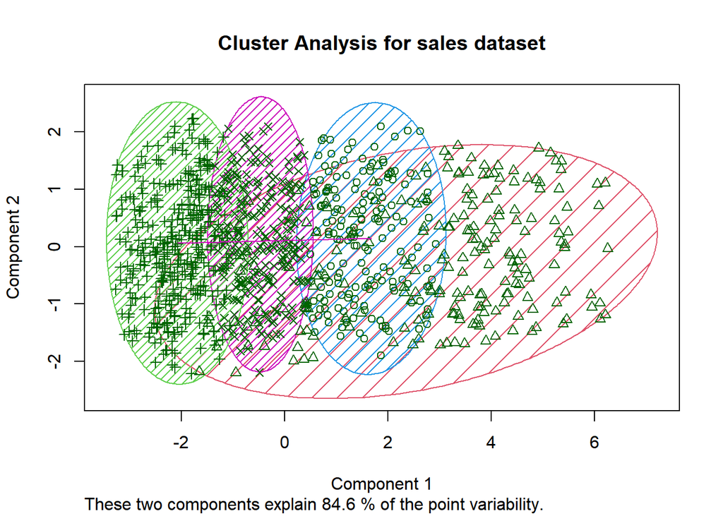

```r
# Loading and installing our cluster package
# ---
#
#suppressWarnings(
       # suppressMessages(if
                        # (!require(cluster, quietly=TRUE))
                #install.packages("cluster")))
library("cluster")

# Cluster Plot against 1st 2 principal components
# ---
#
clusplot(w_norm[1:7], model$cluster, color=TRUE, shade=TRUE,
         labels=6, lines=1,main='Cluster Analysis for sales dataset')
```

observation, with 4 clusters, the two components explains 84.6% of the point variability.

### calculating weight for each cluster

Weights are calculated for each variable and cluster.

They are a measure of the relative importance of each variable with regards to the membership of the observations to that cluster.

The weights are incorporated into the distance function, typically reducing the distance for more important variables.

```r
# checking the Weights
#
round(model$weights*100,3)
```

```
##   Unit.price Quantity    Tax   cogs gross.income Rating  Total
## 1      0.001    0.001 24.999 24.999       24.999  0.001 24.999
## 2      0.001   99.991  0.001  0.001        0.001  0.001  0.001
## 3      0.001    0.001 24.999 24.999       24.999  0.001 24.999
## 4      0.001    0.001 24.999 24.999       24.999  0.001 24.999
```

observation:

In cluster 1, cluster3 and cluster4: Tax, Cogs, gross.income, and Total variables have high weight of 25

### checking correlation.

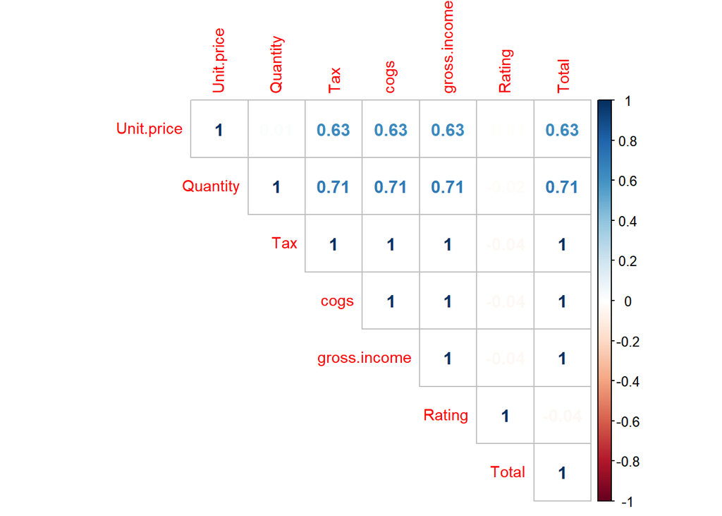

```r
library(caret)
library(corrplot)
#
corrplot(cor(w_norm), type = 'upper', method = 'number', tl.cex = 0.9)
```

### ranking the features

```r
#Scores <- linear.correlation(w_norm)
#Scores
```

```r
# In order to make a decision, we define a cutoff.
# we want to use the top 5 representative variables,
# through the use of the cutoff.k function included in the FSelector package.
# Alternatively, we could define our cutoff visually
# but in cases where there are few variables than in high dimensional datasets.
#
# cutoff.k: The algorithms select a subset from a ranked attributes.

#Subset <- cutoff.k(Scores, 4)
#as.data.frame(Subset)
```

### cutoff based on percentage

```r
# We  set cutoff as a percentage which would indicate
# that we would want to work with the percentage of the best variables.
# ---
#
#Subset2 <-cutoff.k.percent(Scores, 0.5)
#Subset2
```